# PROJET MACHINE LEARNING

Marlene CHEVALIER et Olga SILVA

Juin 2020

# 1 1- Cadrage

L’objectif du projet est de mettre en oeuvre des méthodes d’apprentissage statistique dans un cadre essentiellement prédictif

Le projet porte sur l’analyse de deux fichiers de données concernant une campagne marketing conduite auprès d’un ensemble de clients. Chaque ligne d’un fichier décrit un client. Le fichier projet-app-13-learn.csv contient en outre les résultats de la campagne pour les clients concernées. Les variables sont les suivantes :

- **age** : âge ;
- **sex** : genre ;
- **f_name** : prénom ;
- **last name** : nom;
- **commune** : nom de la commune de résidence ;
- **insee code** : code insee de la commune de résidence ;
- **city type** : type de la commune de résidence ;
- **department** : numéro du département de résidence ;
- **reg** : code de la région de résidence ;
- **catégorie** : code de catégorie socio-professionnelle, selon la table 1 ;
- **revenue** : salaire mensuel en équivalent temps plein (attention, cette information n’est pas disponible pour tous les clients) ;
- **cible** : résultat de la campagne codé par success pour un résultat considéré comme positif et failure dans le cas contraire.

Il est important de noter que Lyon, Paris et Marseille sont découpées en arrondissements et que le nom de commune est alors celui de la ville suivi de l’indication d’arrondissement.

Certaines variables seront naturellement lues comme des variables numériques (par exemple reg et catégorie) alors qu’elles ne contiennent pas des nombres mais des codes. Il est vivement conseillé de convertir les variables concernées au format factor en R pour faciliter la suite des traitements.

Il est aussi vivement conseillé d’enrichir les données fournies par des données annexes, notamment liées à la géographie de la France.

# 2 Contenu du Rapport (Index à construire)

1. Analyse exploratoire minimale des données (statistiques univariées, dépendances, etc.) ;
2. Justification du modèles prédictif choisi ;
3. Description précise de la chaîne de traitement : prétraitements éventuels, ajustement des modèles, choix du modèle, évaluation de ses performances attendues (le rapport doit impérativement contenir un tableau indiquant la qualité numérique attendue pour les prévisions sur le fichier test) ;
4. Analyse de l’importance des variables : cela peut être fait avant l’ajustement des modèles, pendant celui-ci ou après le choix du modèle final. Dans tous les cas, le rapport doit discuter de l’opportunité de construire des modèles sur une partie seulement des variables. Si c’est le cas, les prévisions finales et les performances attendues doivent concerner les modèles n’utilisant que les variables pertinentes ;
5. interprétation du modèle retenu : si cela est possible, une interprétation de la façon dont les décisions du modèle retenu sont prises fournira un complément très important au reste de l’analyse.

# 3 1.Preparation des données

## 3.1 1.1 - Charger les données.

Voici la structure du dataset d’entraînement. Nous avons 10 000 observations et 12 variables

```
## Observations: 10,000
## Variables: 12
## $ age        <int> 42, 28, 28, 55, 39, 76, 50, 32, 29, 59, 85, 58, 67,...
## $ sex        <fct> Female, Female, Male, Male, Male, Female, Male, Mal...
## $ f_name     <fct> WANDA, MAURICETTE, MARTIAL, PHILIPPE, CLÉMENT, EVEL...
## $ last.name  <fct> FAHD, LE BIHAN, DE ALMEIDA, QUILLERE, STANGL, CAVAL...
## $ commune    <fct> Marseille 5e  Arrondissement, Champeaux, Lancié, Be...
## $ insee.code <fct> 13205, 50117, 69108, 21054, 34151, 26106, 67482, 67...
## $ city.type  <fct> Préfecture de région, Commune simple, Commune simpl...
## $ department <fct> 13, 50, 69, 21, 34, 26, 67, 67, 75, 56, 91, 59, 94,...
## $ reg        <int> 93, 28, 84, 27, 76, 84, 44, 44, 11, 53, 11, 32, 11,...
## $ catégorie  <int> 5, 5, 10, 11, 7, 13, 3, 5, 12, 5, 13, 11, 13, 6, 10...
## $ revenue    <dbl> 1260, 1320, NA, NA, 2460, NA, 4500, 1230, NA, 1440,...
## $ cible      <fct> failure, success, failure, success, failure, failur...
```

## 3.2 1.2- Changement du format:

Nous allons renommer la variable catégorie, pour enlever l’accent et convertir celle-ci et la région au format nominal. Il vont nous rester uniquement deux variables en format numérique, l’âge et le revenue

## 3.3 1.3- Completer avec les données géographiques

Ajoutons les coordonnées géographiques et la population. Nous n’avons pas besoin d’ajouter le nom du département pour l’instant.

## 3.4 1.4- Traitement des données manquantes

La variable revenue a 5320 valeurs manquantes pour le dataset de learn (53%) et 5175 pour le dataset de test (51%)

```
##        reg insee.code        age        sex     f_name  last.name
##          0          0          0          0          0          0
##    commune  city.type department  categorie    revenue      cible
##          0          0          0          0       5320          0
##   latitude  longitude          X          Y population     REGION
##          0          0          0          0          0          0
```

```
##        reg insee.code        age        sex     f_name  last.name
##          0          0          0          0          0          0
##    commune  city.type department  categorie    revenue   latitude
##          0          0          0          0       5175          0
##  longitude          X          Y population     REGION
##          0          0          0          0          0
```

**A garder ces graphiques? En annexe?** Voici deux visualisations des données manquantes, qui nous confirmemt qu’uniquement la variable revenus a des valeurs manquantes et ils sont repartis tout au long du dataset

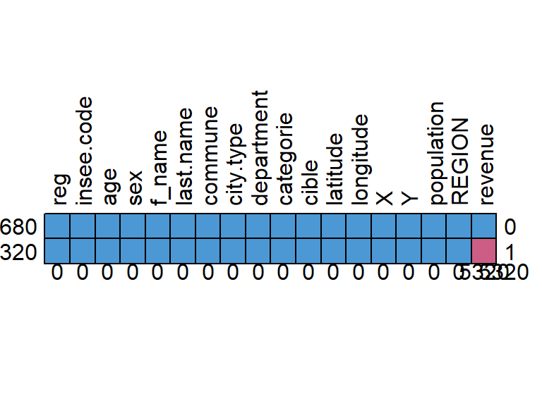

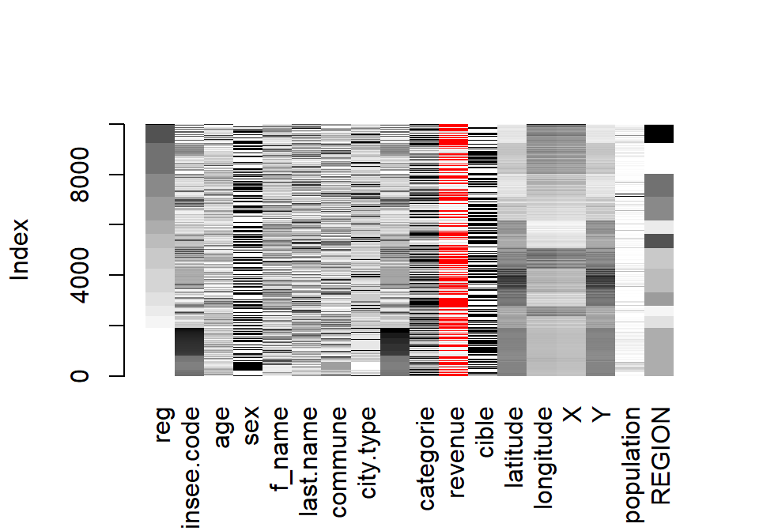

**Pourquoi il y a des valeurs manquantes?**

Avant de traiter ce problème, regardons pourquoi et quand les données sont manquantes. Nous allons uniquement nous concentrer sur la variable revenue.

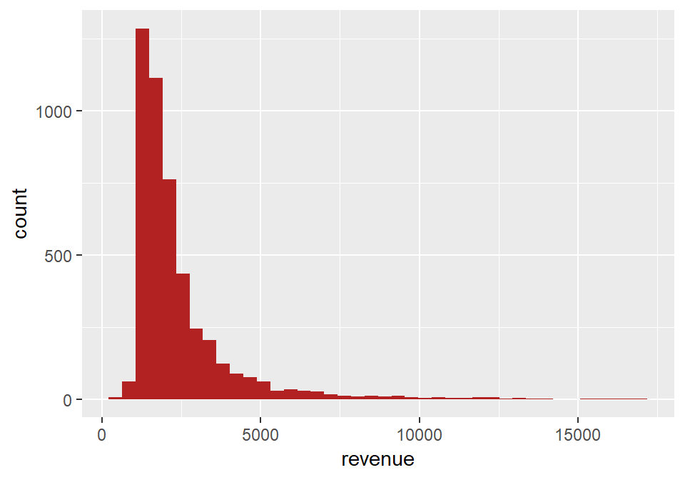

Afin d’avoir plus d’information sur les données manquantes, nous allons utiliser le graphique “Marginplot”. Observons les revenus vs l’âge.

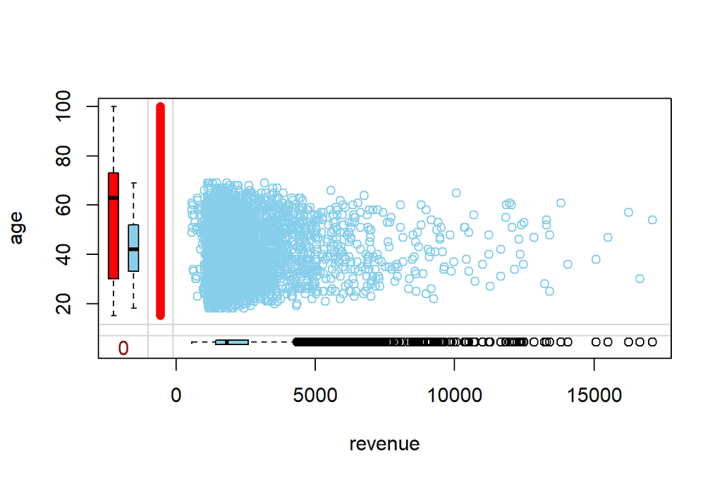

Dans ce graphique, les points sans valeurs manquants apparaissent dans le scatterplot. On observe qu’il manque des valeurs dans toutes les âges (ligne rouge verticale, de 15 à 100 ans). En plus nous avons les boxplots des distributions des valeurs, en rouge quand la valeur est manquante et en bleu quand la valeur est observée.

Les valeurs des revenues sont observées uniquement dans les tranches d’âge entre 18 ans et 69 ans, la période qui pourrait être considérée comme active au niveau professionnel.

Si on observe par rapport à la catégorie :

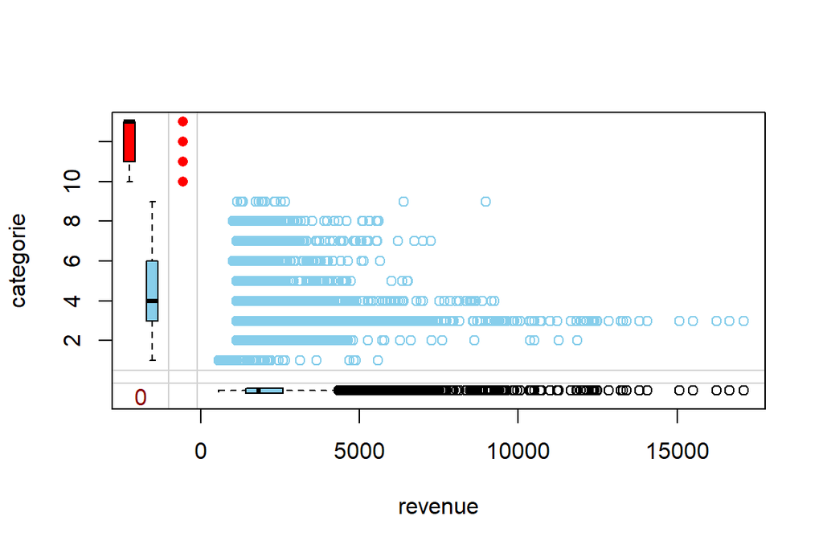

En ce qui concerne le genre, nous avons des données absentes pour les deux catégories, cependant les hommes ont les salaires le plus élevés de l’échantillon.

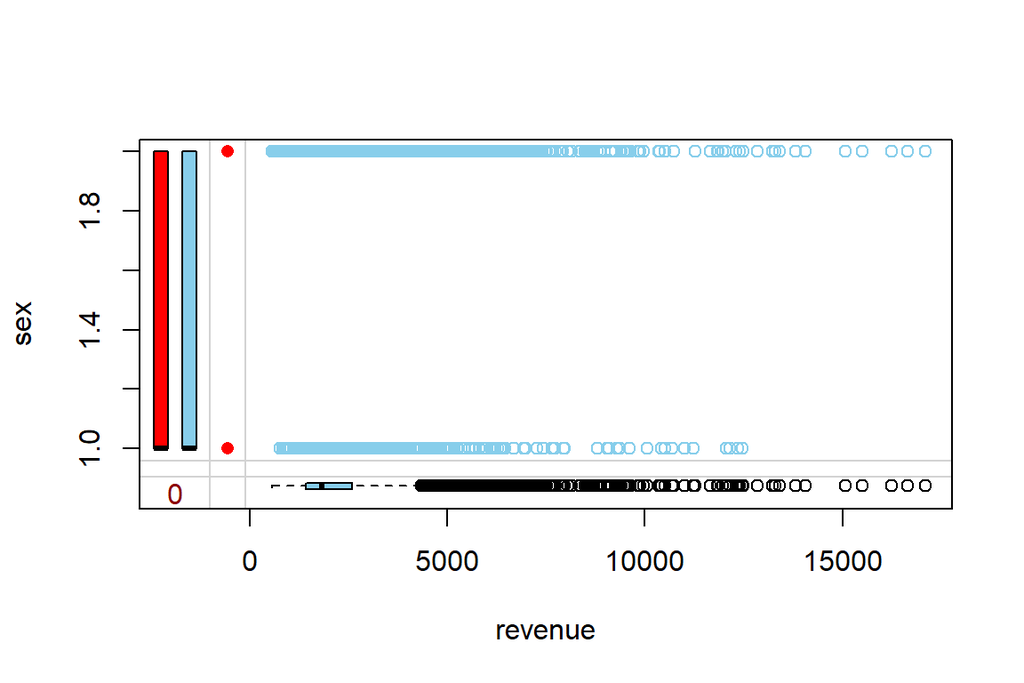

Pour la région aussi, il semblerait aussi que nous avons des données manquantes pour toutes les régions :

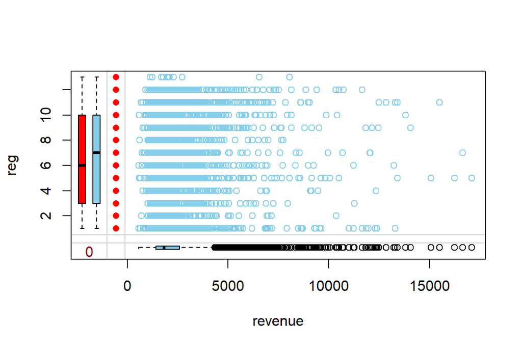

Pour la cible, on observe qu’il y a des données manquantes pour les deux catégories : Failure et success. Mais leur absence n’est pas equilibrée, on retrouve plus des données absentes pour l’échec que pour le succès.

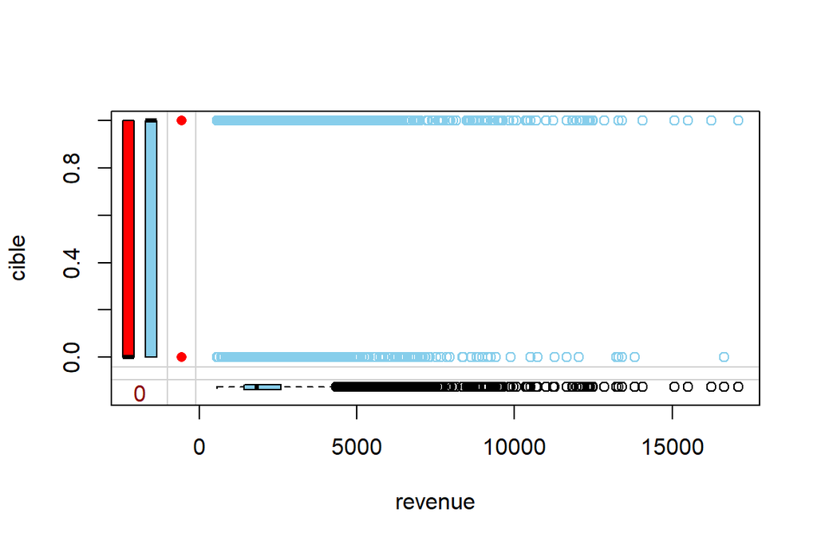

```
## [1] 0
```

```
## [1] 0
```

# 4 2 - Analyse exploratoire des données

Les données semblent bien equilibrées entre les deux catégories à predire : Failure et Success

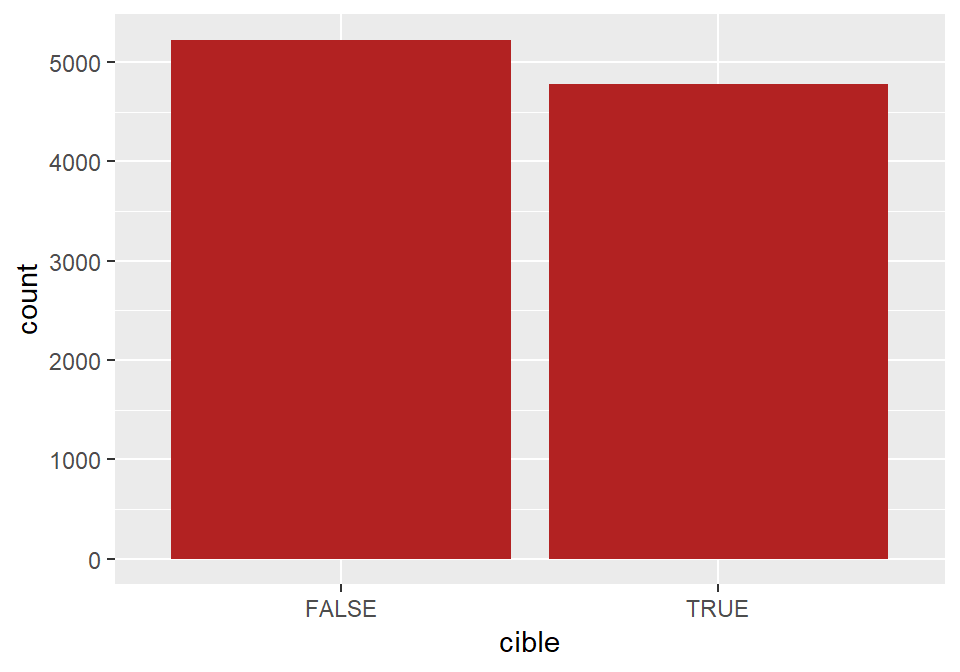

Nous observons une distribution très différente selon l’âge : l’échec est bien répartie entre 25 et 75 ans, par contre le succès est concentré entre 30 et 55 ans, avec quelques valeurs extrêmes superieurs à 75 ans. L’âge est sûrement une variable qui sera pertinente pour la prediction.

Pour la population et les revenues, il ne semble pas avoir des différences.

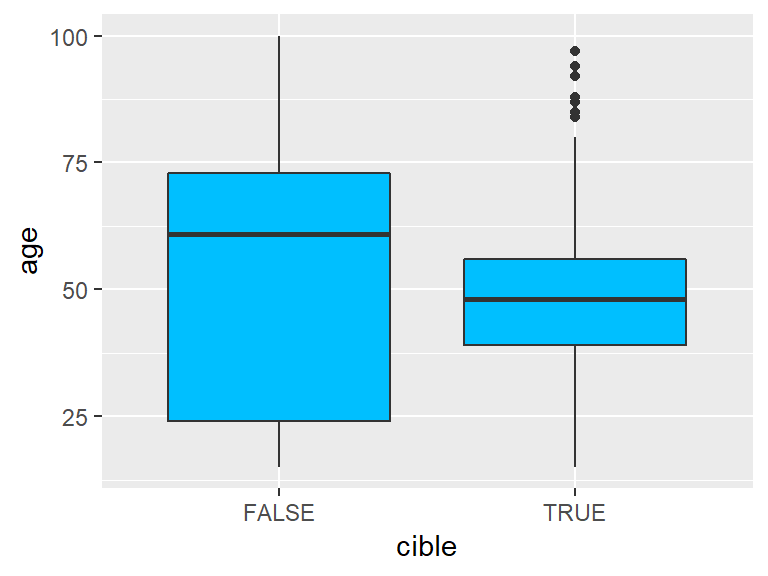

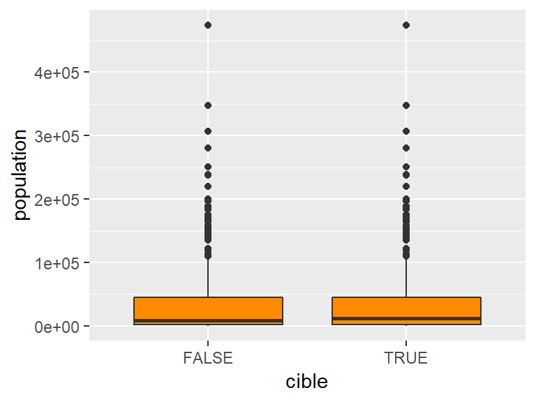

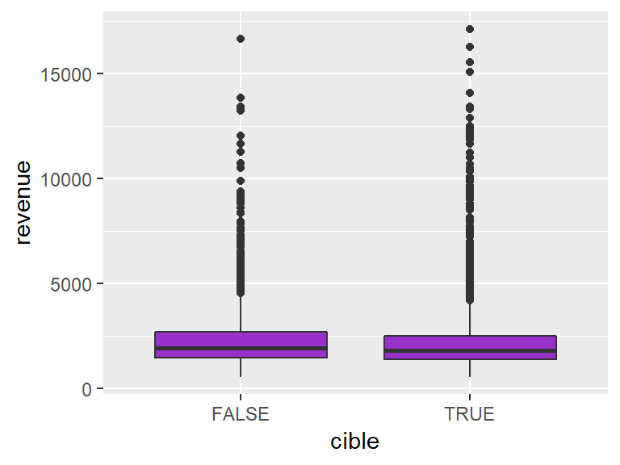

L’échantillon est composé d’un plus grand nombre de femmes que d’hommes (5259 vs 4741)

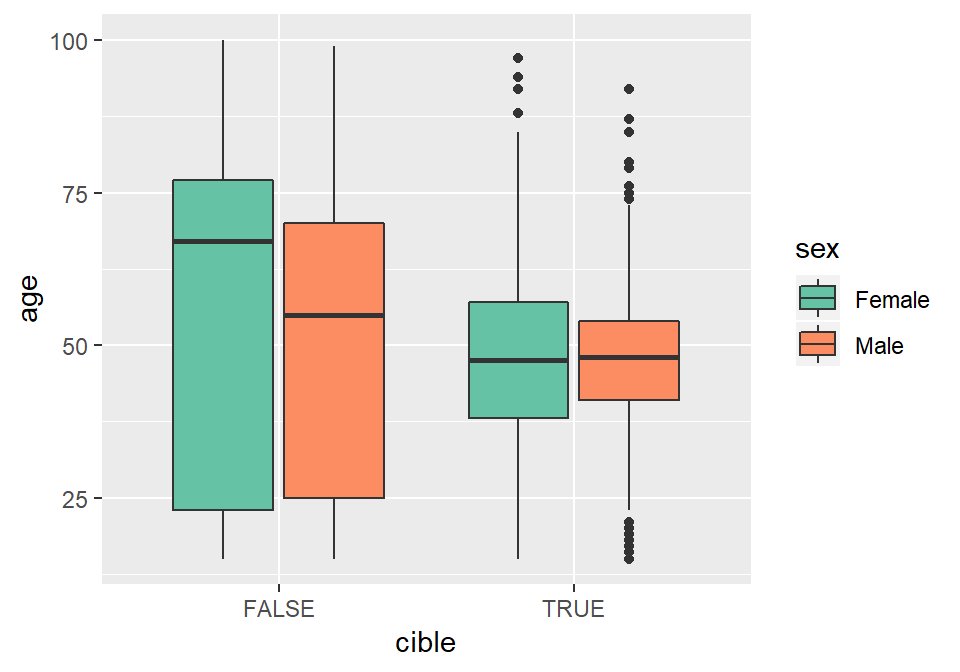

```
##
##          FALSE TRUE
##   Female  2351 2908
##   Male    2870 1871
```

La region Ile de France cumule une bonne partie des resultats, mais en global ils semblent bien equilibrés. Le succes se concentrent dans l’Ile de France

La région Corse a une participation très basse

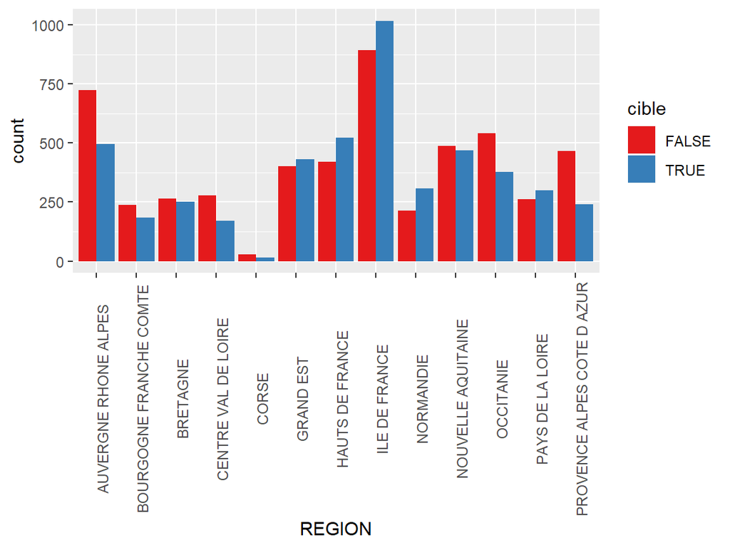

```
##
##                              FALSE TRUE
##   AUVERGNE RHONE ALPES         723  495
##   BOURGOGNE FRANCHE COMTE      237  183
##   BRETAGNE                     264  251
##   CENTRE VAL DE LOIRE          278  171
##   CORSE                         29   14
##   GRAND EST                    402  432
##   HAUTS DE FRANCE              421  522
##   ILE DE FRANCE                894 1017
##   NORMANDIE                    214  309
##   NOUVELLE AQUITAINE           489  469
##   OCCITANIE                    541  377
##   PAYS DE LA LOIRE             262  299
##   PROVENCE ALPES COTE D AZUR   467  240
```

Les retraités et les étudiants (catégorie 13 et 10), enregistrent la plupart des échecs, tandis que les catégories 2 a 8, 11 et 12 (chomeurs et inactifs) ont la plupart des succès, surement il s’agit d’une des variables à garder pour la prédiction.

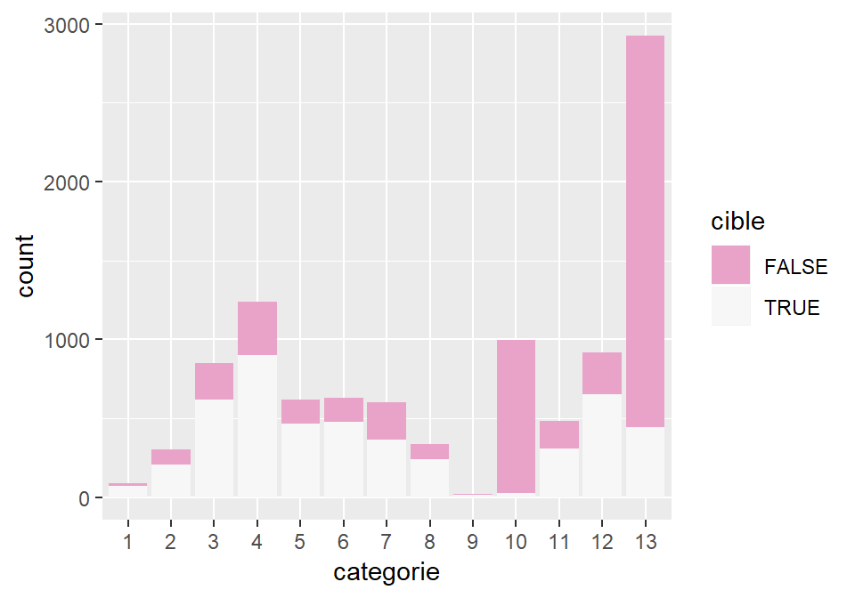

```
##
##      FALSE TRUE
##   1     19   68
##   2     97  205
##   3    233  617
##   4    338  901
##   5    154  466
##   6    149  478
##   7    237  366
##   8     96  239
##   9      4   13
##   10   968   26
##   11   180  305
##   12   266  651
##   13  2480  444
```

Paris, en tant que capitale, enregistre très peu de résultats, en sachant que la région Ile de France c’est la plus représentée dans l’échantillon.

Les âges sont bien reparties entre toutes les types de communes.

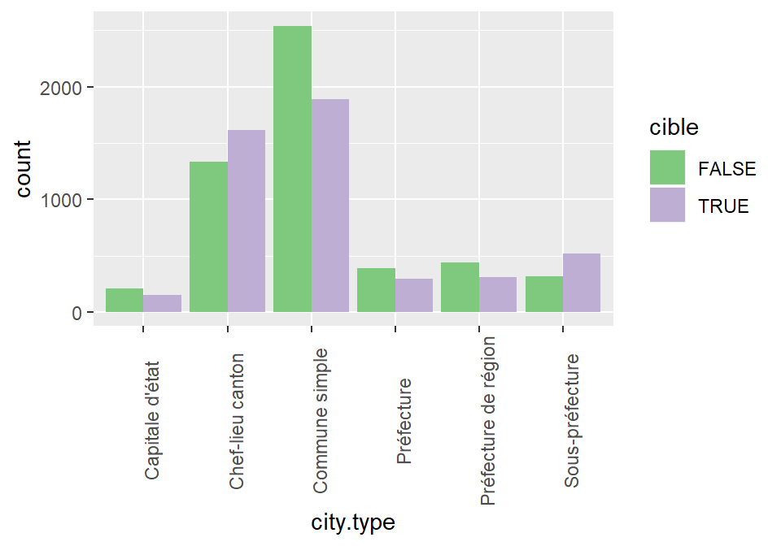

```
##
##                        FALSE TRUE
##   Capitale d'état        206  148
##   Chef-lieu canton      1331 1615
##   Commune simple        2541 1890
##   Préfecture             389  293
##   Préfecture de région   437  312
##   Sous-préfecture        317  521
```

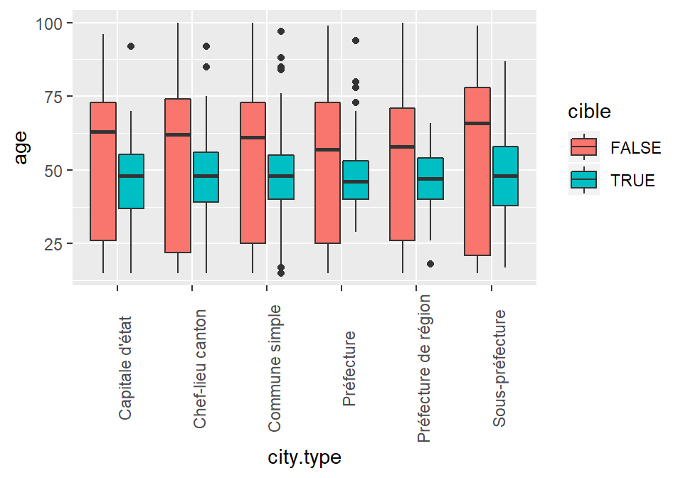

Voici la repartition des reponses sur toute la france, on observe plus de succèss au nord et plus des echecs au sud (region Auvergne-Rhône-Alpes):

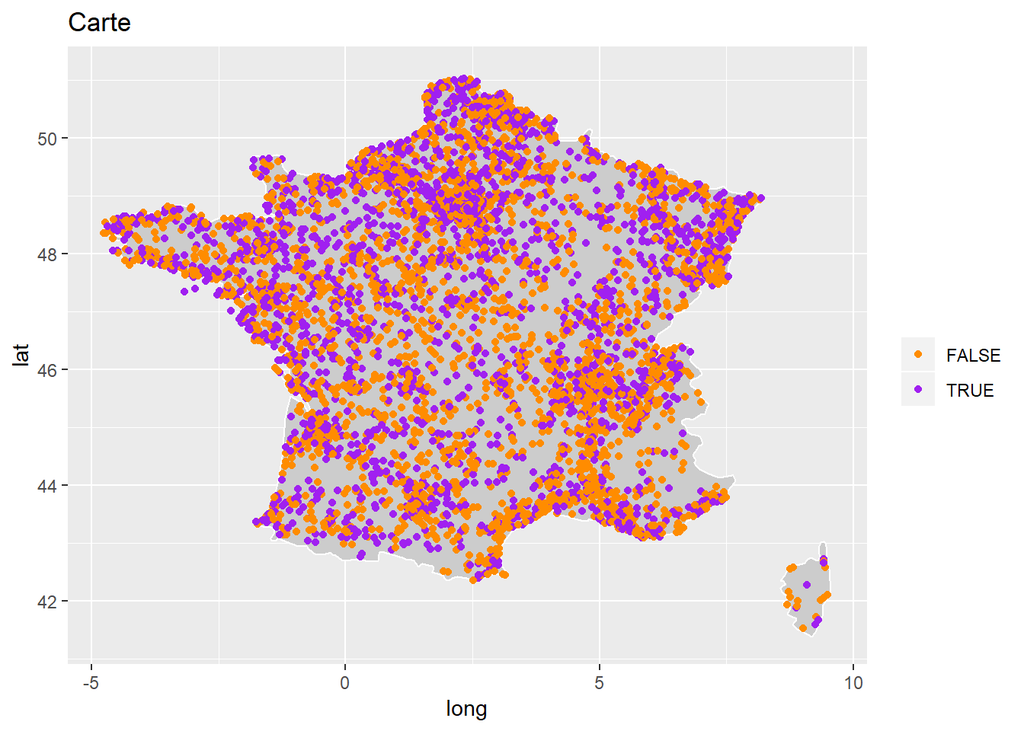

Ce graphique montre que les variables qui vont beaucoup influencer notre prediction seront surement l’age et la categorie.

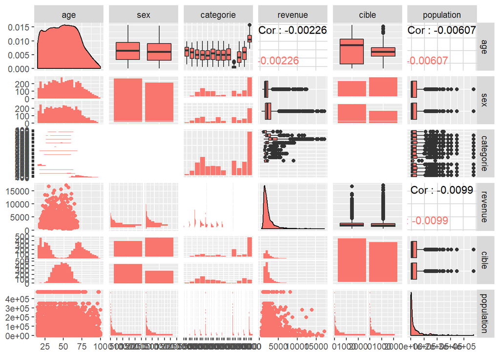

# 5 3 - Ajustement des modèles

## 5.1 3.1 - Régression logistique**

**Validation croisée**

Nous créons d’abord la partition de données, avec 70% pour l’entrainement et 30% pour la validation. Nous sortons les variables qui ne semblent pas apporter d’information.

Ensuite nous utilisons la fonction GLM, pour faire une régression logistique :

```
##
## Call:
## glm(formula = cible ~ categorie + age + sex + city.type + REGION +
##     population, family = binomial(logit), data = train)
##
## Deviance Residuals:
##     Min       1Q   Median       3Q      Max
## -2.6923  -0.6071  -0.1236   0.6502   3.1905
##
## Coefficients:
##                                    Estimate Std. Error z value Pr(>|z|)
## (Intercept)                      -1.423e+00  4.465e-01  -3.187 0.001435
## categorie2                       -5.789e-01  3.915e-01  -1.479 0.139261
## categorie3                       -3.957e-01  3.748e-01  -1.056 0.291131
## categorie4                       -3.907e-01  3.705e-01  -1.054 0.291715
## categorie5                       -5.374e-01  3.826e-01  -1.405 0.160132
## categorie6                       -8.165e-01  3.823e-01  -2.135 0.032725
## categorie7                       -6.655e-01  3.762e-01  -1.769 0.076848
## categorie8                       -2.742e-01  3.941e-01  -0.696 0.486645
## categorie9                       -2.532e-01  9.232e-01  -0.274 0.783897
## categorie10                      -4.338e+00  4.365e-01  -9.939  < 2e-16
## categorie11                      -6.243e-01  3.826e-01  -1.632 0.102785
## categorie12                      -8.948e-01  3.729e-01  -2.399 0.016426
## categorie13                      -5.691e+00  3.832e-01 -14.850  < 2e-16
## age                               5.702e-02  2.962e-03  19.252  < 2e-16
## sexMale                          -1.348e+00  7.375e-02 -18.273  < 2e-16
## city.typeChef-lieu canton         1.163e+00  2.105e-01   5.522 3.35e-08
## city.typeCommune simple           5.007e-01  2.208e-01   2.267 0.023364
## city.typePréfecture               6.105e-01  2.281e-01   2.676 0.007444
## city.typePréfecture de région     2.771e-01  2.307e-01   1.201 0.229791
## city.typeSous-préfecture          2.055e+00  2.344e-01   8.769  < 2e-16
## REGIONBOURGOGNE FRANCHE COMTE     3.263e-01  1.837e-01   1.777 0.075648
## REGIONBRETAGNE                    3.511e-01  1.746e-01   2.011 0.044292
## REGIONCENTRE VAL DE LOIRE         8.664e-02  1.769e-01   0.490 0.624211
## REGIONCORSE                      -1.714e-01  4.958e-01  -0.346 0.729610
## REGIONGRAND EST                   8.475e-01  1.502e-01   5.643 1.67e-08
## REGIONHAUTS DE FRANCE             1.037e+00  1.444e-01   7.181 6.94e-13
## REGIONILE DE FRANCE               9.046e-01  1.285e-01   7.038 1.95e-12
## REGIONNORMANDIE                   1.350e+00  1.702e-01   7.930 2.19e-15
## REGIONNOUVELLE AQUITAINE          7.596e-01  1.396e-01   5.440 5.34e-08
```

[output cut: 33 more lines]

```
## REGIONNOUVELLE AQUITAINE         ***
## REGIONOCCITANIE
## REGIONPAYS DE LA LOIRE           ***
## REGIONPROVENCE ALPES COTE D AZUR ***
## population                       .
## ---
## Signif. codes:  0 '***' 0.001 '**' 0.01 '*' 0.05 '.' 0.1 ' ' 1
##
## (Dispersion parameter for binomial family taken to be 1)
##
##     Null deviance: 9691.8  on 7000  degrees of freedom
## Residual deviance: 5849.7  on 6968  degrees of freedom
## AIC: 5915.7
##
## Number of Fisher Scoring iterations: 6
```

Le modele qu’il a choisit avec le meilleure AIC est : cible ~ categorie + age + sex + REGION + city.type. Il semblerait dans ce choix que la variable “population” ne soit pas pertinente.

AIC: 5832.4

**Prediction**

Voici la matrice de confusion quand le seuil est fait à 50% :

```
##
##         FALSE TRUE
##   FALSE  1258  197
##   TRUE    308 1236
```

L’erreur de prediction que nous obtenons est de :

```
## [1] 0.1683895
```

Nous pouvons optimiser cette prédiction, en trouvant le seuil optimal :

```
## [1] 0.4917019
```

```
##
##         FALSE TRUE
##   FALSE  1252  189
##   TRUE    314 1244
```

et son nouvel erreur de prédiction est plus bas :

```
## [1] 0.1677226
```

```
## [1] "Accuracy 0.832277425808603"
```

**Ajustement du modèle**

Graphique des résidus

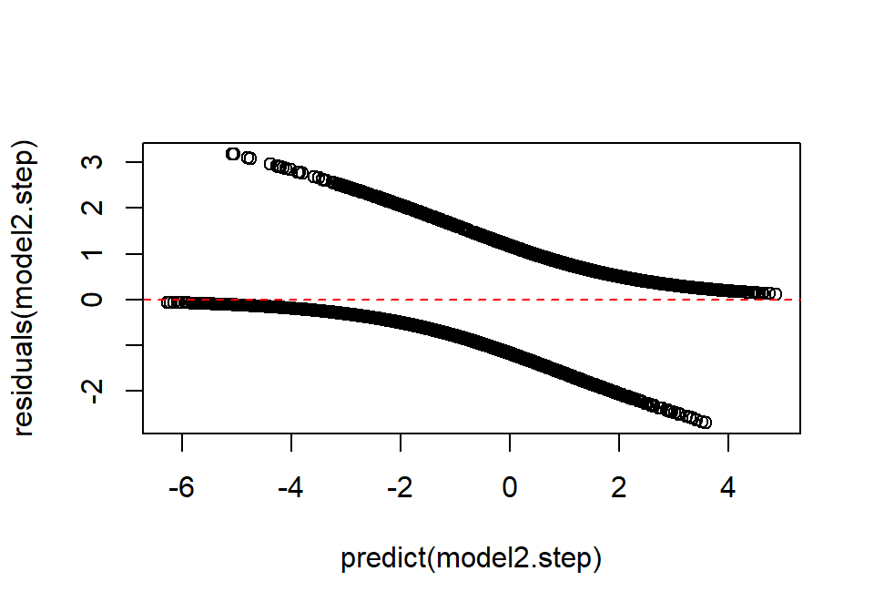

**ROC** :

Comme dernière étape nous allons construire la courbe ROC et calculer l’AUC (area under the curve), qui sont des mesures de performance très connues lors de la classification.

La courbe ROC est faite en mettant le TPR (True positive rate) vs FPR (False positive rate), avec plusieurs seuils, et l’AUC est l’aire sous la courbe ROC

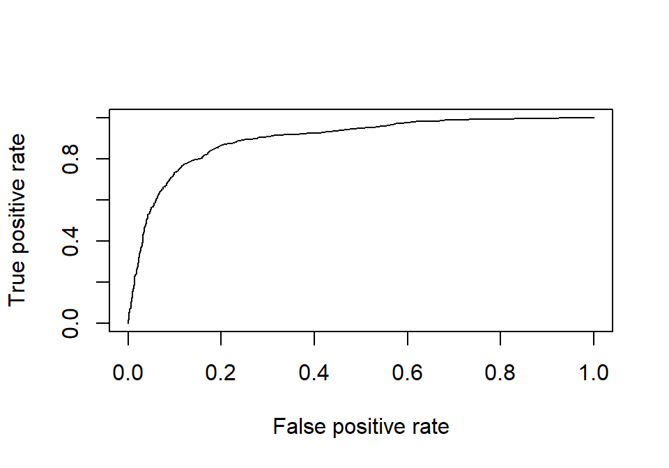

AUC : un modèle avec une bonne capacité prédictive devrait avoir l’AUC le plus proche de 1 que de 0,5.

```
## [1] 0.8962688
```

## 5.2 3.2 - Arbres de Décision

**Validation croisée**

Comme pour la régression logistique, nous allons faire nos partitions avec 70% pour l’entrainement et 30% pour la validation.

**Création du premier arbre**

Nous allons faire notre premier arbre sans ajuster les paramêtres de contrôle de l’arbre, avec les paramètres par défaut de la fonction rpart (minsplit = 20, minbucket = round(minsplit/3), cp = 0.01)

Voici le graphique de l’arbre qui est produit avec rpart:

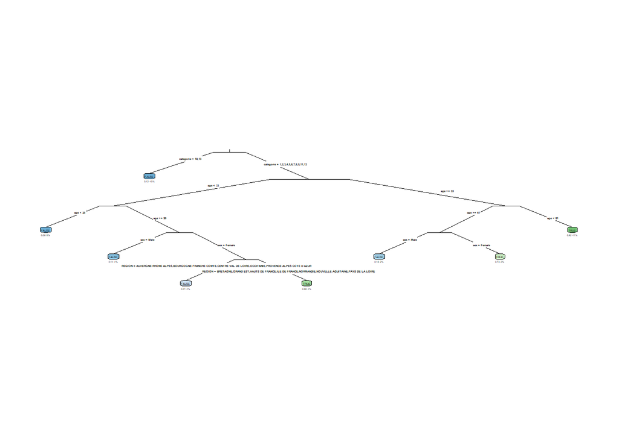

rpart utilise l’impureté Gini pour sélectionner les divisions lors de la classification. L’impureté Gini est la probabilité de classer incorrectement un élément choisi au hasard dans l’ensemble de données, s’il était étiqueté de manière aléatoire en fonction de la distribution des classes. L’impureté Gini de 0 est le plus bas possible, il est possible quand toutes les données sont dans la même class.

Avec ce graphique, chaque noeud montre :

- La classe prédite (TRUE ou FALSE)
- La probabilité d’être VRAI
- Pourcentage d’observations dans chaque noeud

**Zoom sur le CP**

Le CP (complexity parameter) est utilisé pour contrôler la croissance de l’arbre et sélectionner la taille optimal de l’arbre. Si le coût d’ajouter une variable est plus élevé que la valeur du CP, la croissance s’arrête.

Les fonctions **printcp** et **plotcp** fournissent l’erreur de validation croisée pour chaque nsplit et peuvent être utilisées pour élaguer l’arbre. Celui avec le moins d’erreur de validation croisée (xerror) est la valeur optimale de CP.

Avec plotcp, il vous montre également l’endroit optimal pour élaguer l’arbre. Un bon choix de CP pour l’élagage est souvent la valeur la plus à gauche pour laquelle la moyenne se situe en dessous de la ligne horizontale, dans notre cas 0,01, la valeur par défaut.

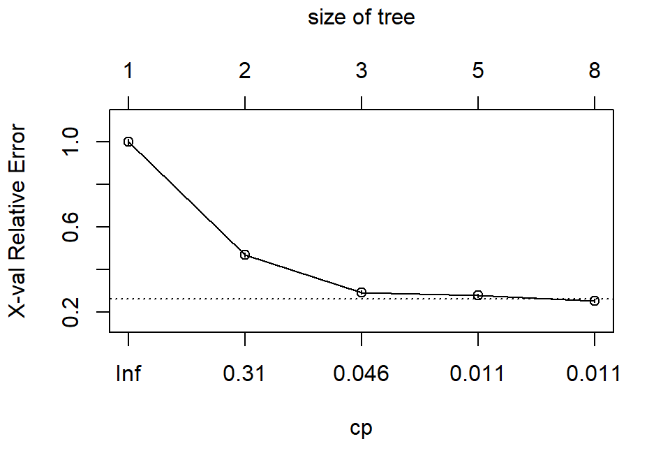

Pour la fonction **printcp**, chaque ligne représente une hauteur différente de l’arbre. En général, plus de niveaux dans l’arbre signifient qu’il a moins d’erreur de classification sur l’entrainement. Cependant, il existe le risque d’overfitting. Souvent, l’erreur de validation croisée augmentera à mesure que l’arbre atteindra plus de niveaux (au moins, après le niveau «optimal»).

```
##
## Classification tree:
## rpart(formula = cible ~ ., data = train_arbre, method = "class")
##
## Variables actually used in tree construction:
## [1] age       categorie REGION    sex
##
## Root node error: 3346/7001 = 0.47793
##
## n= 7001
##
##         CP nsplit rel error  xerror      xstd
## 1 0.530185      0   1.00000 1.00000 0.0124911
## 2 0.179916      1   0.46981 0.46981 0.0104347
## 3 0.011955      2   0.28990 0.29378 0.0086875
## 4 0.011058      4   0.26599 0.27824 0.0084911
## 5 0.010000      7   0.23192 0.25344 0.0081590
```

sans surprise la meilleure valeur est 0,01

**Matrice de confusion et ROC**

```
##
## tree.pred FALSE TRUE
##     FALSE  1417  191
##     TRUE    149 1242
```

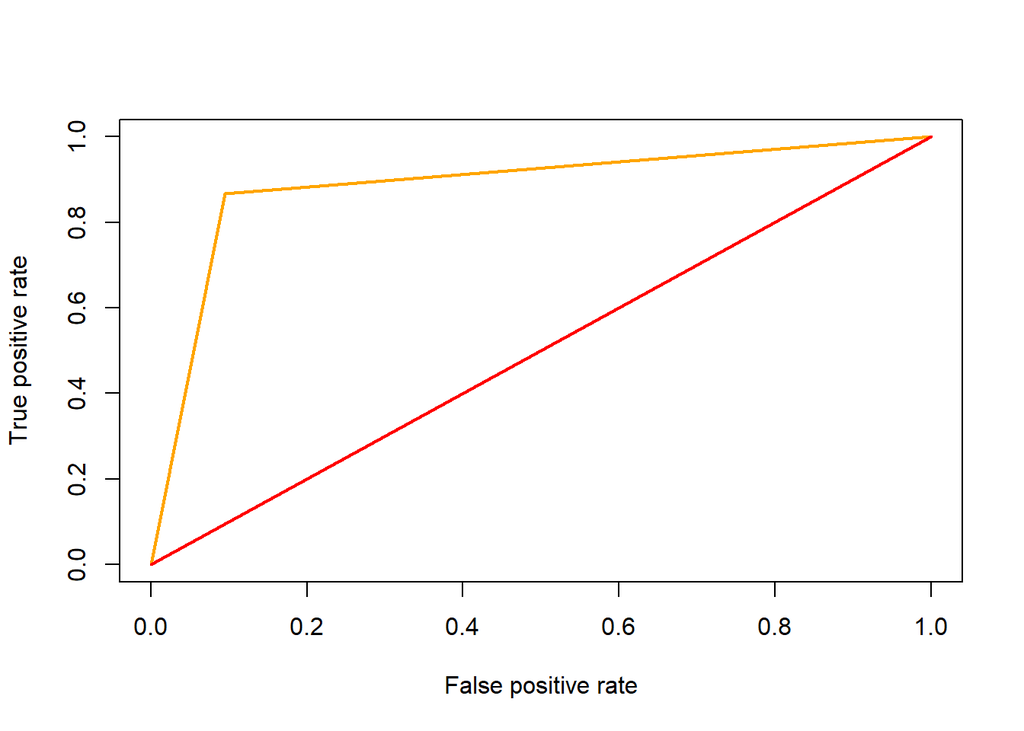

```
## [1] 0.8857832
```

**Tuner l’arbre**

Nous allons aussi modifier le paramètre “minsplit”, il contrôle le nombre minimum d’observations qui doit exister dans un nœud pour qu’une tentative de division soit faite.

Nous allons démarrer avec le CP = 0.0001, et minsplit =2

[figure not shown]

**Solution - Imputation des données**

Pour que l’imputation fonctionne, il faut enlever des colonnes avec trop de catégories, et celles qui ne devraient pas apporter plus d’information comme le prénom et le nom.

L’imputation avec mice, sera faite avec rf : “Random forest imputation”, en utilisant les données d’age, sex, region, categorie et population pour trouver le revenue correspondant.

# 6 2 Modèles prédictives (à suivre)